# Notes on PaCMAP

### Effect of PCA

coil20

frey

oli

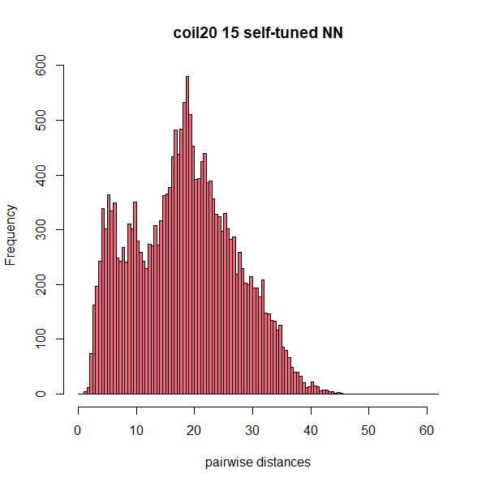

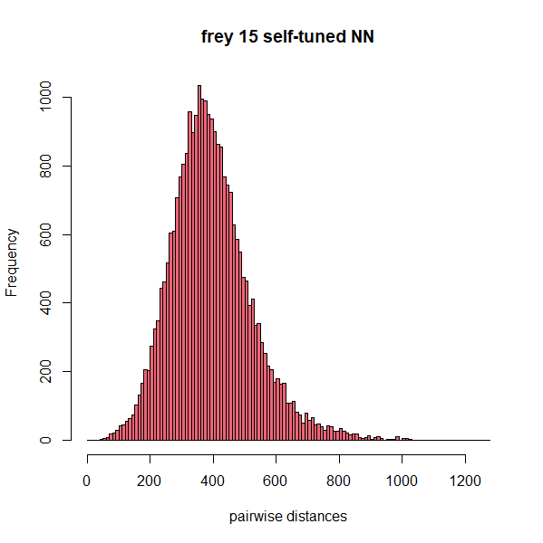

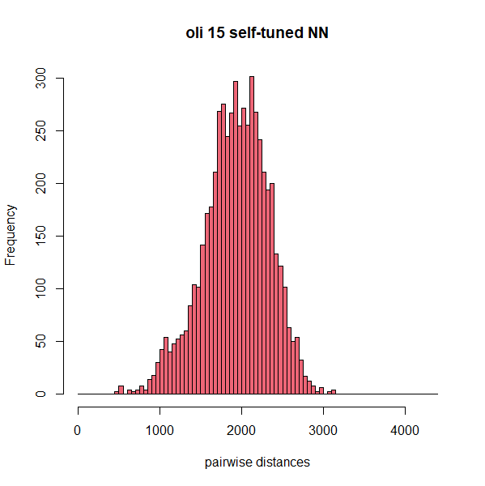

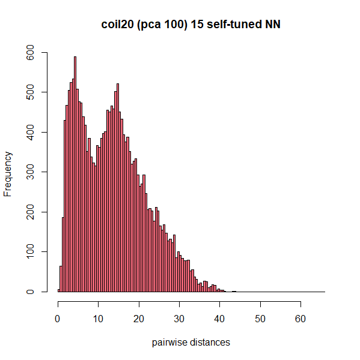

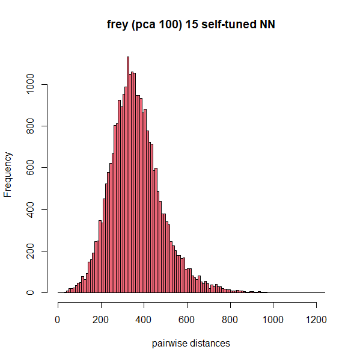

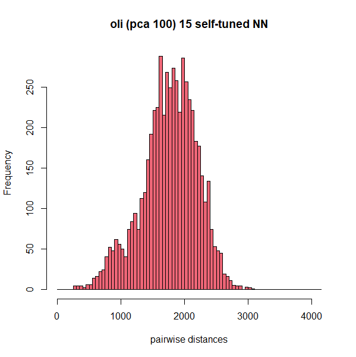

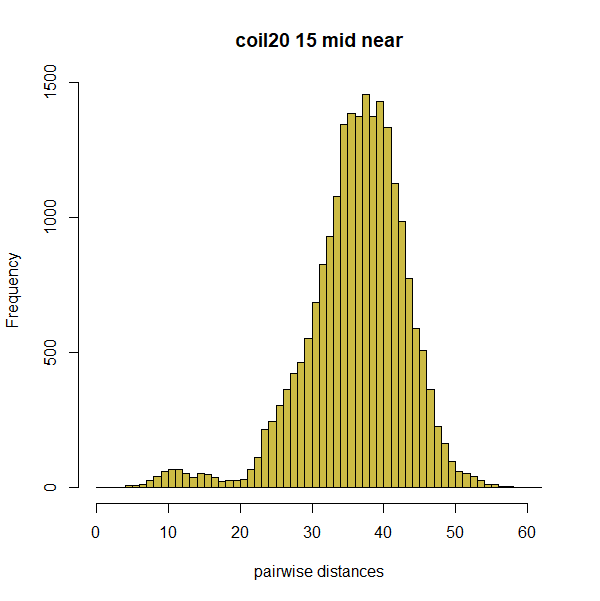

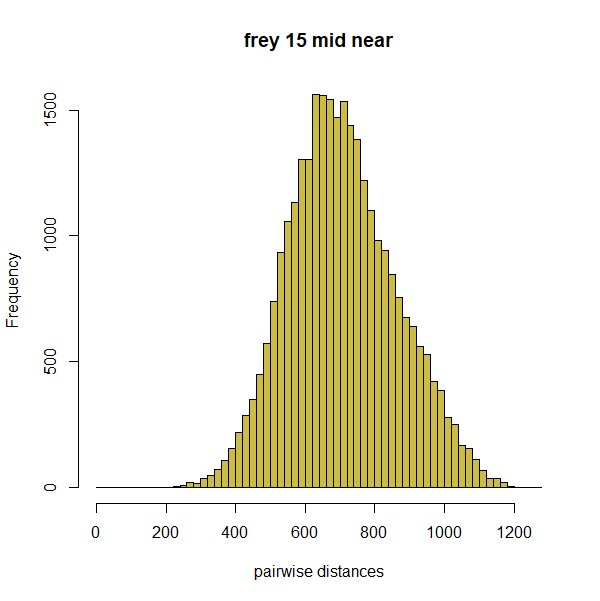

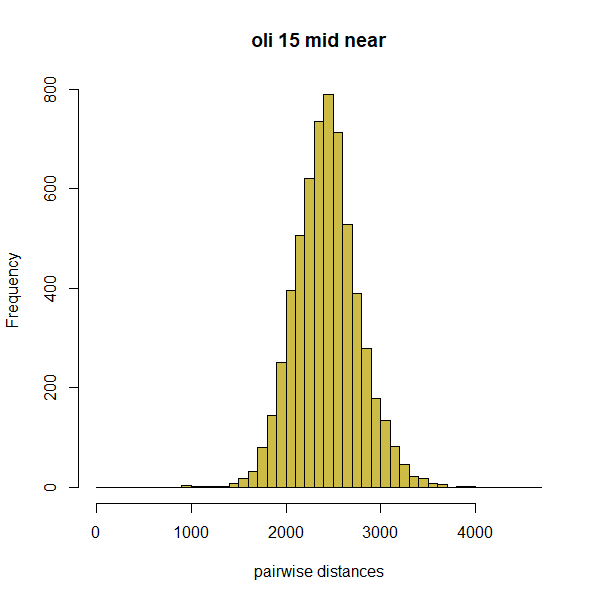

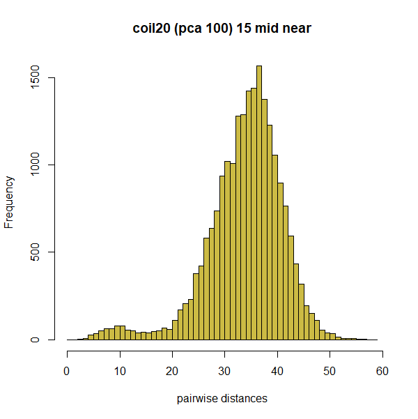

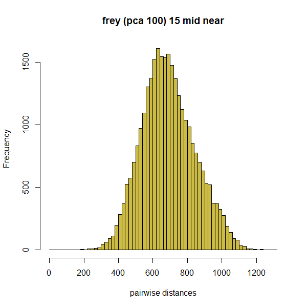

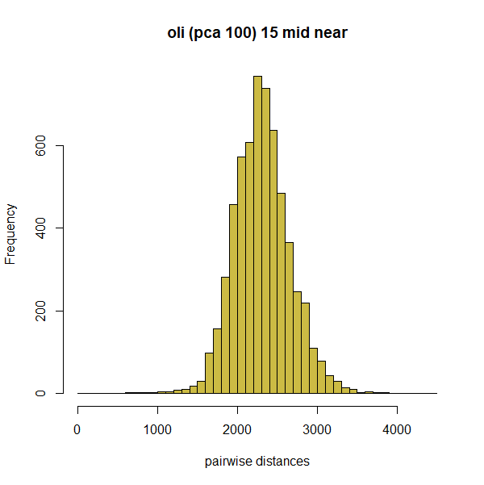

mnist

fashion

kuzushiji

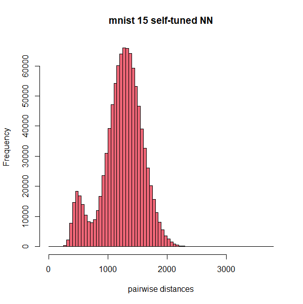

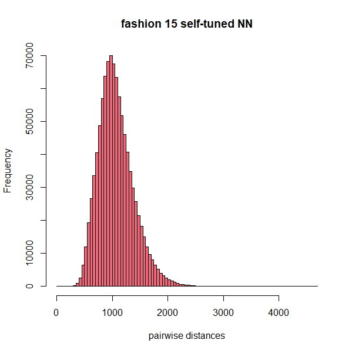

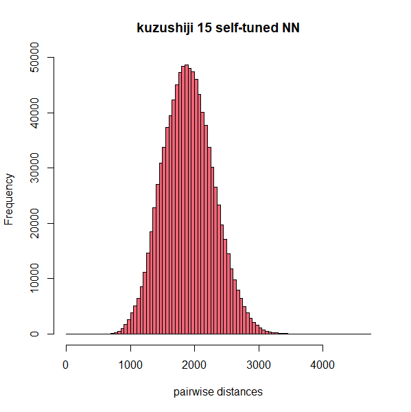

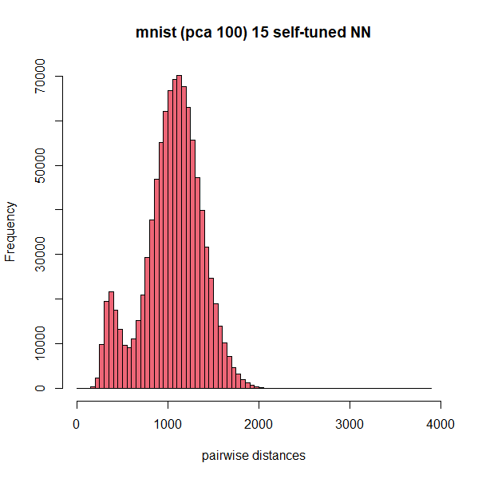

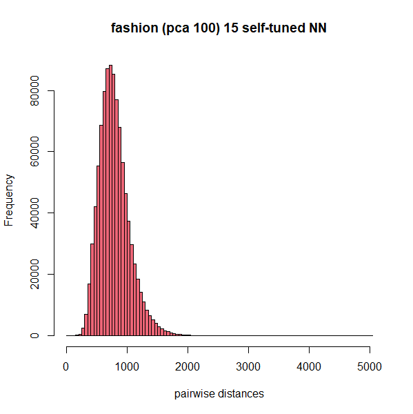

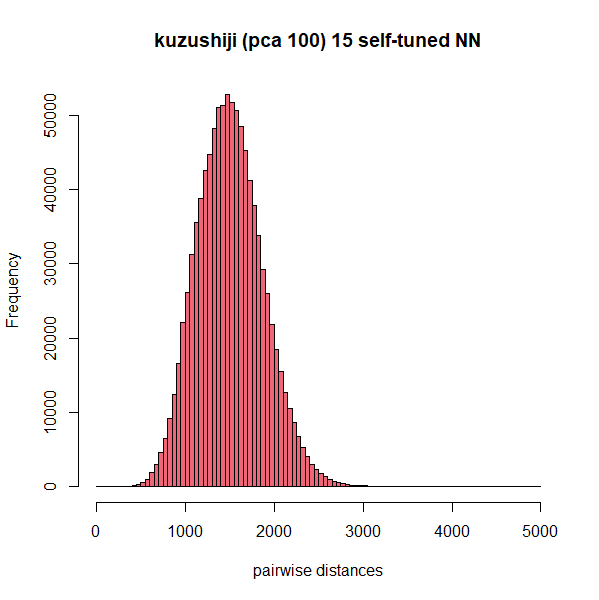

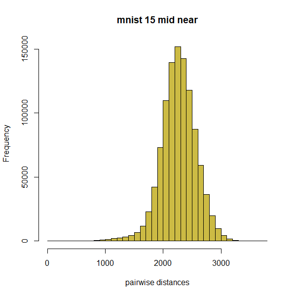

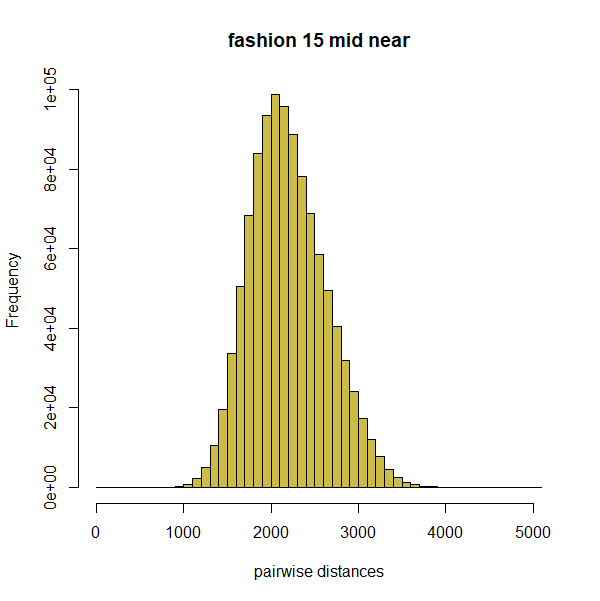

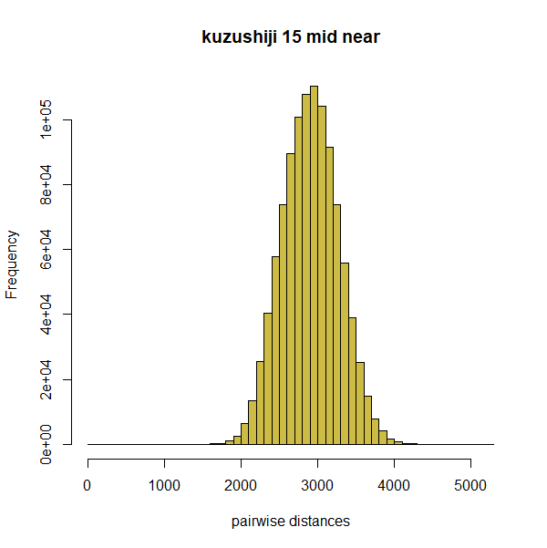

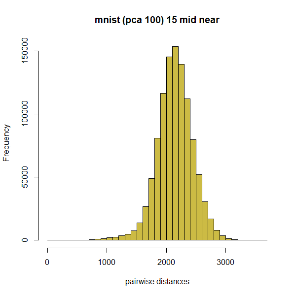

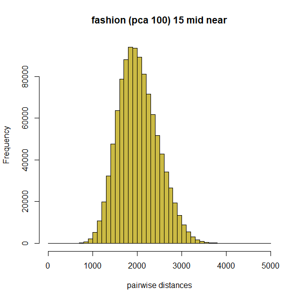

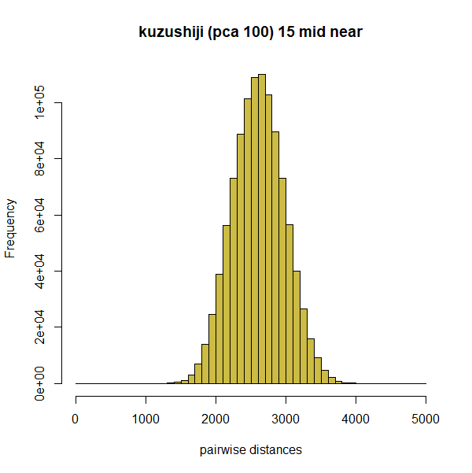

cifar10

macosko2015

tasic2018

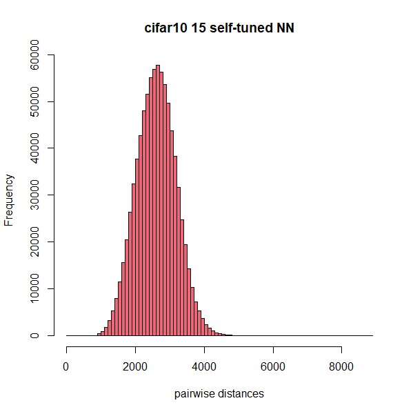

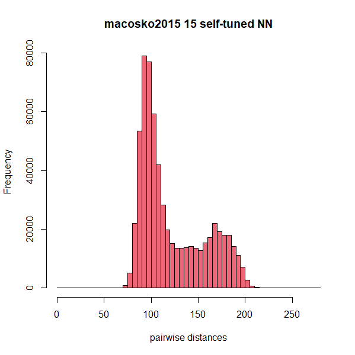

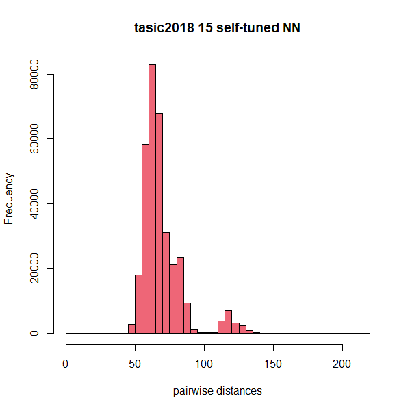

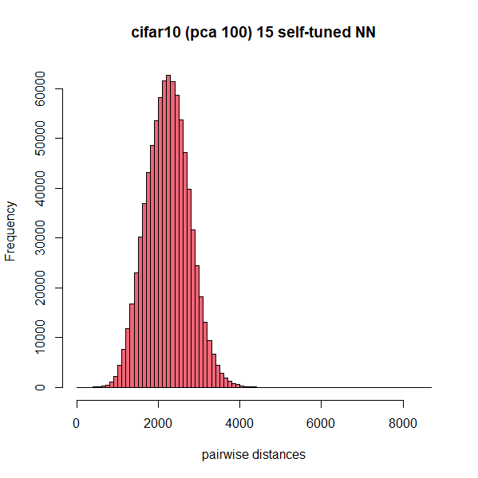

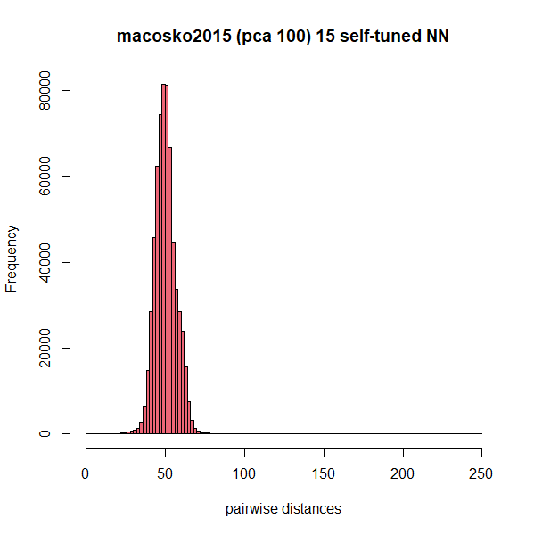

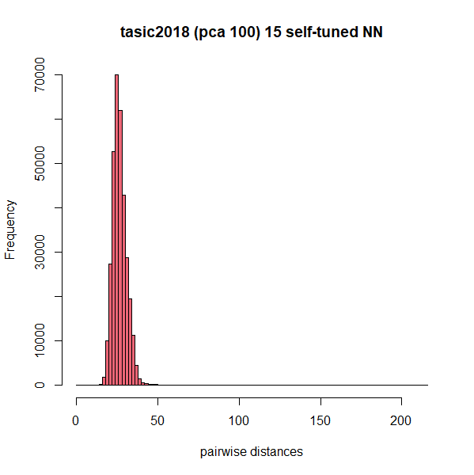

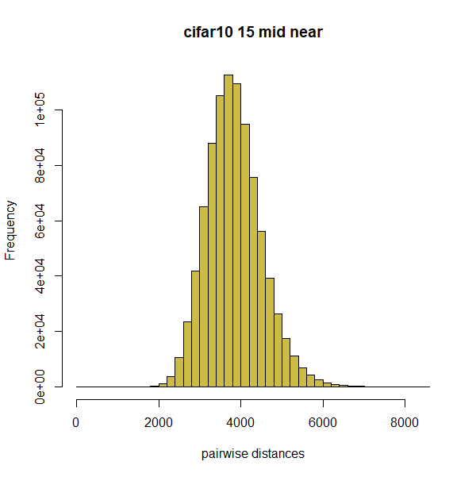

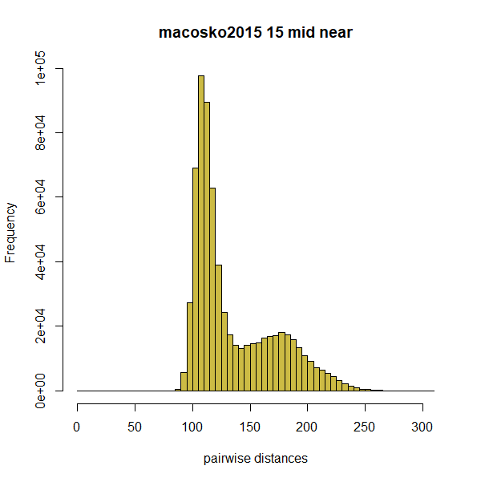

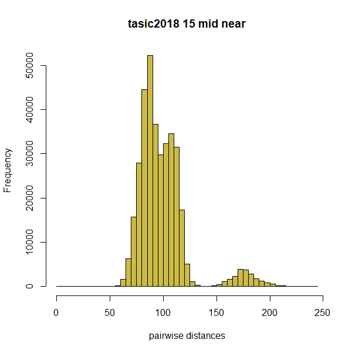

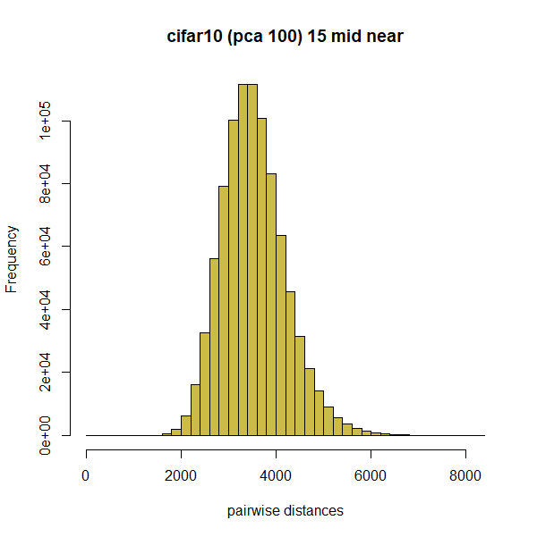

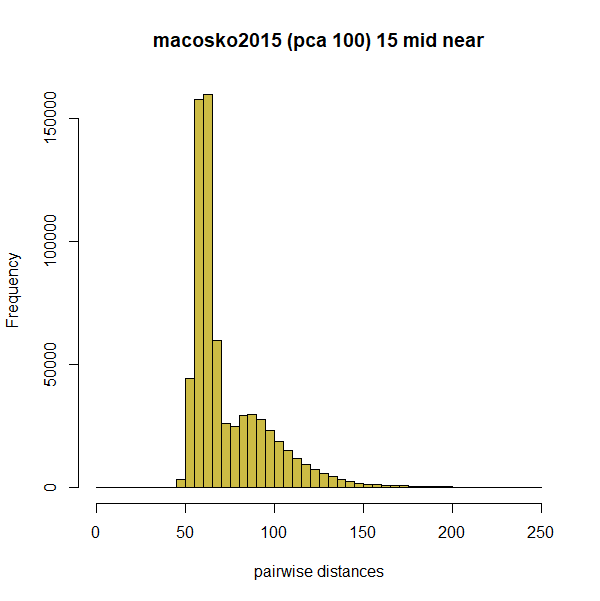

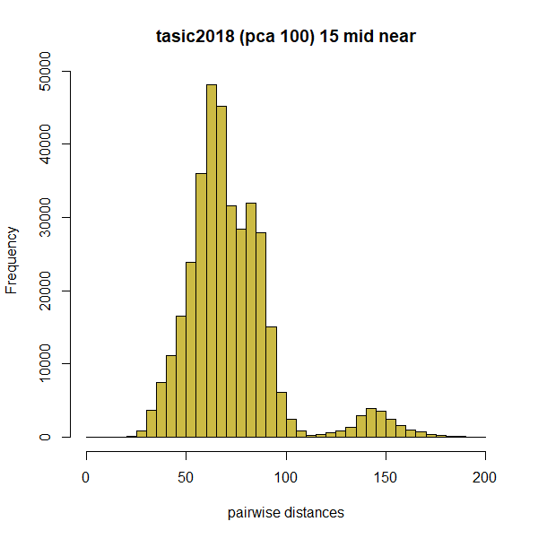

`macosko2015` does indeed show a pretty dramatic change in its distribution, particularly its nearest neighbors. `tasic2018` also seems to show this. Could just be coincidence that those are both RNA-seq datasets, but probably a look at how such datasets are normalized or otherwise pre-processed might be in order. For the other datasets, PCA doesn’t seem to distort the distributions as much. However, as they are all image datasets, that doesn’t necessarily mean that there aren’t problems lurking. Memo to self: find some non-image datasets, e.g. the 20 Newsgroup dataset (available in the PaCMAP repo) for text categorization.

### 20NG

*December 25 2021*: I followed up on my memo to myself and have now looked at the [20 Newsgroups](http://qwone.com/~jason/20Newsgroups/) dataset aka `20NG`, but I will refer to it as `ng20` because variables which begin with a digit are difficult or impossible to work with in most programming languages.

Currently, the PaCMAP repo has [20NG data](https://github.com/YingfanWang/PaCMAP/blob/f309fb8faef55a80e819ab91c8f81ac7d3937d9a/data/20NG.npy) available, but this is a dense numpy matrix with 100 features, so presumably it has already been reduced down by the Truncated SVD. As I want to compare this with a higher rank decomposition, I processed the 20NG data from scratch. The 20NG dataset is sparse, and PaCMAP does not support sparse input data (Annoy does not support sparse distance calculations), so some kind of pre-processing of the data to produce a dense matrix is required.

I took the dataset preparation from this [UMAP example](https://umap-learn.readthedocs.io/en/latest/sparse.html#a-text-analysis-example) (note that UMAP can work on sparse inputs directly because it uses [pynndescent](https://github.com/lmcinnes/pynndescent/) to find nearest neighbors). The simple procedure I followed was:

```python
import sklearn.datasets
import sklearn.feature_extraction.text
from sklearn.decomposition import TruncatedSVD

ng20v =  sklearn.datasets.fetch_20newsgroups_vectorized(subset="all")
ng20tfidf = sklearn.feature_extraction.text.TfidfTransformer(norm="l2").fit_transform(ng20v.data)

svd = TruncatedSVD(3000)
ng20tfidf_svd3000 = svd.fit_transform(ng20tfidf)
```

For the data here, I used L2 normalization because L1 (as used in the UMAP example) results in some documents having very few near neighbors, which leads to most of the histograms being squashed to the left side of the plots due to a small number of large distances. The L2 normalization also gives distance distributions and UMAP and PaCMAP embeddings which are closer to the results I get when using the PaCMAP data. So I am sticking with L2 normalization for consistency and legibility (but I have no opinion on whether the L1 or L2 normalization is “better” for this dataset).

As noted above in the “Input Preprocessing” section, I have some doubts that the default settings for Truncated SVD in sklearn always produces the truncated SVD. However, for this data it did a fine job: the dot products of each column with the next column was always below $10^{-14}$, which is good enough for me. I also tried with [irlba](http://bwlewis.github.io/irlba/) in R, but on this occasion it was irlba that had trouble converging with its default parameters (increasing the `work` parameter fixed this issue). In terms of the distributions for the 100 and 3000 dimension distances, results seemed very comparable, so I am sticking with the Python TruncatedSVD results below.

The above procedure isn’t completely ideal because PaCMAP centers its input before performing PCA via SVD. The above is just a low-rank approximation via SVD. I don’t actually know how to safely combine centering with SVD on a sparse matrix with TruncatedSVD (irlba is able to implicitly center sparse data). Fortunately, for calculating Euclidean distances, the difference doesn’t matter.

Below is a comparison of the distance distributions using 3000 columns vs 100.

ng20 15s

ng20 mid

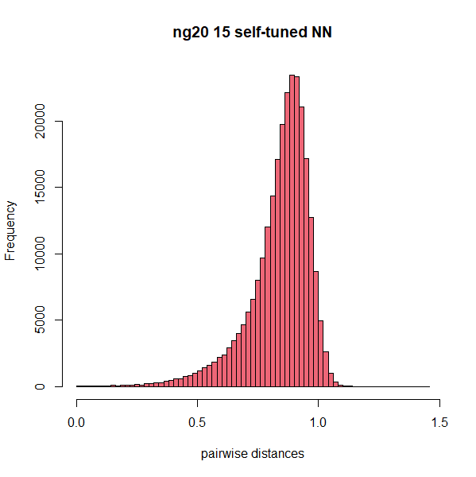

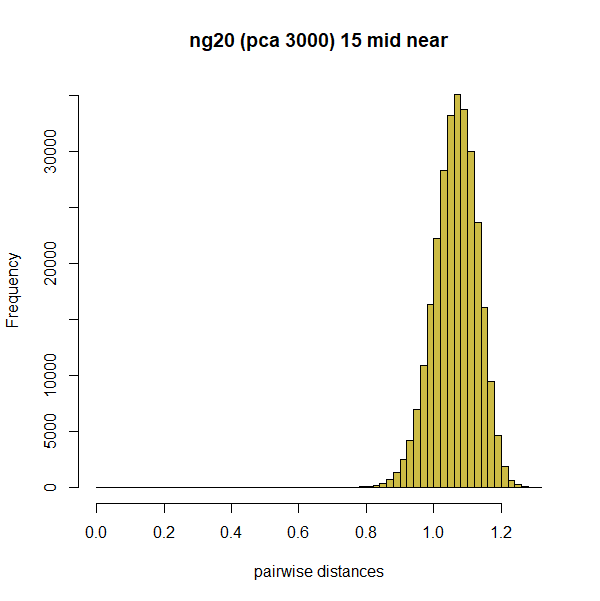

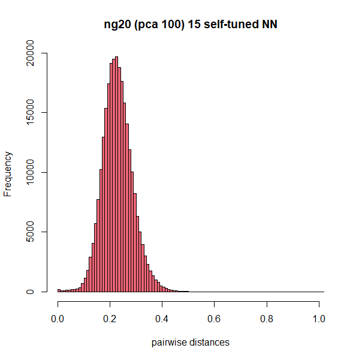

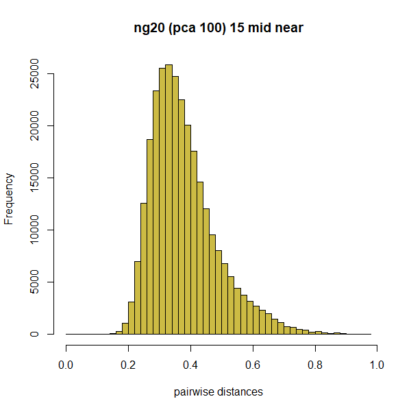

Again, there is a noticeable shift in the distributions. The point here isn’t whether keeping 3000 columns vs 100 columns results in better embeddings (the 100D result actually seems better and you would probably use the cosine metric instead of Euclidean for this dataset), but that the distributions of distances is noticeably shifted for some datasets, which is something to be aware of. If you only look at the MNIST digits for example, you *won’t* see this shift which might lull you into believing that reducing dimensionality to 100 PCs gives you a speed increase for the nearest neighbor search with no other downstream effects.

## Quantifying the effect of PCA and scaled distances

Here is an attempt to quantify how PCA and the scaled distances affects the nearest neighbors, using overlap of different nearest neighbors lists and the hubness of the dataset.

### Overlap with exact nearest neighbors

In the table below I list the mean overlap for each dataset between different neighbor lists, i.e. for each item in a dataset, I calculate the overlap of two different neighbor lists, and then scale by the length of the list, so that an overlap of 0 means there no neighbors in common, and 1 means the neighbor lists are identical. In the table below, the average over all items in each dataset is reported.

I look at using PCA with 100 dimensions, and when generating the scaled 15 nearest neighbors, select the 15 from the 65 nearest neighbors based on the unscaled distances. These are the PaCMAP defaults.

There are a *lot* of numbers reported here. I’ll try and explain why I am interested in each column:

- `15 vs PCA15`: the overlap of the 15 nearest neighbors in the original space vs after doing PCA. The 15 nearest neighbors without PCA applied to them is what UMAP would use by default. If PCA is mainly acting as a way to reduce the initial dimensionality without having an effect on the local neighborhoods, I would expect the overlap to be large in this case.
- `150 vs PCA150`: same as the above, but looking at 150 nearest neighbors: if the overlap for 15 neighbors is low, but larger for 150 nearest neighbors, then the local neighborhood is getting distorted a bit by PCA, but the same points are still “nearby”. This assumes you believe that 150 nearest neighbors still represents a “local” neighborhood vs 15 neighbors. In my experience, UMAP local structure is rarely strongly affected by using 150 nearest neighbors vs 15, so I think it’s an ok assumption for our purposes here. The more nearest neighbors you look at, the larger the overlap will be: in the limit of choosing the size of the dataset as the nearest neighbors, the overlap will always be 1, but for most datasets, the proportion of the dataset that we return with 15 vs 150 neighbors isn’t a big change, except maybe for for the `oli` dataset, but it’s never been a dataset that has provided any particular issues for embedding with UMAP or t-SNE, so I am unconcerned.
- `15 vs 15s`: the overlap between the 15 nearest neighbors in the original space vs after local scaling. No PCA is applied in either case. Here we would hope that the overlap would be reduced, or there would be no point in carrying out the re-scaling. On the other hand, too little overlap might be also a bit worrying as we would hope some of the local neighborhood would be retained.
- `PCA15 vs 15s`: if PCA has an effect and local scaling (without PCA) has an effect on the local neighborhoods, how similar are they? Do they tend to choose the same neighborhoods?
- `15 vs PCA15s`: this compares the 15 nearest neighbors without any PCA or local scaling, with those after carrying out PCA *and* local scaling. This is a direct comparison of how UMAP and PaCMAP decide on the local neighborhood.
- `PCA15 vs PCA15s`: for this column I am curious to know how much of an effect local scaling has after applying PCA. In particular, seeing what the numbers are like compared to the equivalent comparison without PCA involved in the `15 vs 15s` column. Is the overlap the same or are there some trends?

After writing all that out, I feel like I definitely might not be a lot of fun at parties, but here we are. Also `mammoth`, `sch10k` and `curve2d` don’t have enough columns to be reduced to 100D, they are excluded from any PCA-based comparison.

| dataset | 15 vs PCA15 | 150 vs PCA150 | 15 vs 15s | PCA15 vs 15s | 15 vs PCA15s | PCA15 vs PCA15s |
| --- | --- | --- | --- | --- | --- | --- |
| mammoth |  |  | 0.8952 |  |  |  |
| sch10k |  |  | 0.9185 |  |  |  |
| curve2d |  |  | 0.9808 |  |  |  |
| oli | 0.9555 | 0.9862 | 0.7488 | 0.7662 | 0.7347 | 0.7538 |
| frey | 0.9661 | 0.9806 | 0.7943 | 0.8086 | 0.7883 | 0.8042 |
| coil20 | 0.944 | 0.9491 | 0.8538 | 0.8733 | 0.8343 | 0.8623 |
| mnist | 0.8694 | 0.9077 | 0.765 | 0.7624 | 0.7312 | 0.7798 |
| fashion | 0.7496 | 0.8219 | 0.6946 | 0.6936 | 0.6073 | 0.7432 |
| kuzushiji | 0.8059 | 0.8341 | 0.7238 | 0.704 | 0.6709 | 0.7334 |
| cifar10 | 0.749 | 0.8064 | 0.4718 | 0.5845 | 0.3953 | 0.5286 |
| macosko2015 | 0.1201 | 0.1321 | 0.4071 | 0.1575 | 0.1045 | 0.6609 |
| tasic2018 | 0.4805 | 0.715 | 0.7155 | 0.5281 | 0.4419 | 0.8124 |
| ng20 | 0.2705 | 0.1608 | 0.5883 | 0.3052 | 0.278 | 0.6974 |

Looking at the first two columns it does seem that PCA doesn’t have a big effect on the overlap of nearest neighbors for a lot of datasets. The three obvious exceptions are `macosko2015`, `tasic2018` and `ng20`. Going to 150 nearest neighbors helps for `tasic2018`, but does very little for `macosko2015`. For `ng20` the overlap with 150 nearest neighbors is actually worse than for 15 nearest neighbors.

This confirms my fears about the cavalier use of PCA for preprocessing: it might be a good idea to do it, but it does have an effect on the results of the nearest neighbors so you should have a good reason for doing it (and in the case of PaCMAP why 100 dimensions is the magic number). *January 14 2022*: see [Cooley and co-workers](https://doi.org/10.1101/689851) for a similar argument about the effect of PCA (and UMAP and t-SNE) on preserving neighborhoods. They use the Jaccard distance (sometimes referred to as Tanimoto) with 20-nearest neighbors on a variety of single cell RNAseq datasets.

Looking at the scaled nearest neighbors, this has a more consistent effect on neighborhoods than PCA. For datasets like `oli` and `frey` where PCA retained more than 90% of the neighborhoods, local scaling retains 75% and 79%. At the other end of the scale, where applying PCA to `macosko2015` resulted in a 12% neighborhood preservation, local scaling retains 41%.

The `PCA15 vs 15s` results shows that there isn’t a consistent overlap between applying PCA vs local scaling, i.e. PCA and local scaling could return different neighborhoods, so whatever effect PCA has in the cases like `macosko2015`, it’s not that a similar effect to local scaling (even though a smaller dimensionality should result in the reduction of hubs).

The `15 vs PCA15s` column shows how many neighbors we would expect PaCMAP to have in common with UMAP with default-ish settings. The answer is: not that much, depending on the dataset. Only `coil20` has more than 80% overlap on average.

To summarize: you can expect that local scaling *does* change the neighbors that are considered to be close. The degree of change that occurs after local scaling is quite similar whether you apply PCA or not (I would expect 25-50% change in the neighbors on average with the setting here), but applying PCA *could* have a very big effect on the neighbors. Or it might do very little.

### Hubness

The preceding section indicates that both PCA and local scaling can affect the local neighborhoods that are used in dimensionality reduction. A possible good outcome for either approach might be to reduce hubness in the dataset.

Hubness of a dataset measures if there are some items which are disproportionately “popular” with other items in the dataset. This can reduce the usefulness of a nearest neighbor graph in a variety of settings. So in most cases you will want to trade exact accuracy over the nearest neighbors of a nodes for something that makes reaching arbitrary nodes in other parts of the graph easier: for example if you are searching a graph by hopping from node to node via edges, having hubs mean that some nodes will be reached disproportionately often which could be a waste of time depending on your needs. In dimensionality reduction methods involving sampling edges like UMAP and PaCMAP, a node that shows up as part of a very large number of edges may end up distorting the optimization in a way that makes the visualization unhelpful.

For hubness, I measure the number of times an item appears in the $k$-nearest neighbor list of the items in the dataset (the [k-occurrence](https://www.jmlr.org/papers/v11/radovanovic10a.html)): this can take a value from 0 to $N$ (where $N$ is the number of items in the dataset), so I scale the values by $N$, so the range is 0-1. The maximum k-occurrence across the dataset is then the hubness. You can interpret the resulting value as the proportion of the dataset that the most “hubby” point in the data is connected to. In the case where there are no hubs, we would expect every point to be on $k$ other neighbor lists, so the hubness would be $k/N$.

In the table below, I first report the hub-free hubness value as `k/N`. Then the rest of the columns are the calculated hubness using the following definitions of nearest neighbors: the 15 nearest neighbors, the 15 nearest neighbors after PCA, the 15 scaled nearest neighbors, and the 15 scaled nearest neighbors after PCA. I would hope that the scaled nearest neighbors result in reduced hubness: [Schnitzler and co-workers](https://jmlr.org/papers/v13/schnitzer12a.html) explicitly recommend it as a way to reduce hubness.

| dataset | k/N | 15 nn | PCA 15 nn | 15 snn | PCA 15 snn |
| --- | --- | --- | --- | --- | --- |
| mammoth | 0.0015 | 0.003 |  | 0.0028 |  |
| sch10k | 0.001579 | 0.002736 |  | 0.002631 |  |
| curve2d | 0.01034 | 0.01517 |  | 0.01517 |  |
| oli | 0.0375 | 0.2175 | 0.2025 | 0.0825 | 0.08 |
| frey | 0.007634 | 0.02239 | 0.02087 | 0.01527 | 0.01476 |
| coil20 | 0.01042 | 0.03194 | 0.02847 | 0.02083 | 0.02153 |
| mnist | 0.0002143 | 0.001129 | 0.0009857 | 0.0005 | 0.0004714 |
| fashion | 0.0002143 | 0.0036 | 0.001514 | 0.001357 | 0.0006286 |
| kuzushiji | 0.0002143 | 0.002786 | 0.0015 | 0.0006714 | 0.0005571 |
| cifar10 | 0.00025 | 0.03202 | 0.01208 | 0.00285 | 0.00165 |
| macosko2015 | 0.0003348 | 0.2262 | 0.01192 | 0.02071 | 0.00154 |
| tasic2018 | 0.0006297 | 0.01696 | 0.00701 | 0.004114 | 0.002225 |
| ng20 | 0.0007959 | 0.7064 | 0.01894 | 0.09063 | 0.003184 |

`oli` has a surprisingly high hubness: there is one point that is a neighbor of 20% of the dataset. Meanwhile, most other datasets don’t have a high hubness, i.e. they are all below 0.05 (no point is a neighbor of more than 5% of the rest of the dataset). At this point it should be no surprise that the exceptions are `macosko2015` and `ng20`.

The table shows there are also two effective measures for reducing hubness: local scaling, as recommended by Schnitzler and co-workers does seem to help a lot. For datasets which didn’t have any problem with hubness, the hubness can go up a tiny bit, but not in a way that seems very concerning. This is an effect that was also noted by Schnitzler and co-workers.

PCA is also effective and for `macosko2015` and `ng20` reduces the hubness more than scaling the original raw distances, and in general combining PCA and scaling results in the lowest hubness.

Although the histograms of the distances showed only a minor effect of scaling the distances, these numbers suggest that testing the effect of using the scaled nearest neighbors would be a useful thing to try with UMAP.

## See Also

- Cynthia Rudin’s [dimensionality reduction course notes (PDF)](https://users.cs.duke.edu/~cynthia/CourseNotes/DataVizLectureNotes.pdf).
- Some notes on the related method [NCVis](https://jlmelville.github.io/smallvis/ncvis.html).

## R Code for Plots

```r
# generate force constants over a range of w
pacmap_k <- function(a = 1, b = 10, n = 100, max_w = 0.99) {
  w <- (1:n) / n
  w <- w[w < max_w]
  ka <- (2 * a * b * w * w) / ((1 + b * w) ^ 2)
  kr <- (-2 * w * w) / ((1 + w) ^ 2)
  list(attr = ka, rep = kr, w = w)
}

umap_k <- function(a = 1.577, b = 0.895, n = 100, eps = 1e-3, max_w = 0.99) {
  w <- (1:n) / n
  w <- w[w < max_w]
  d2 <- ((1 - w) / (a * w)) ^ (1 / b)
  d2b1 <- d2 ^ (b - 1)

  ka <- 2 * a * b * d2b1 * w
  kr <- (-2 * b * w) / (eps + d2)
  list(attr = ka, rep = kr, w = w)
}

uk <- umap_k()
tk <- umap_k(a = 1, b = 1)
pk <- pacmap_k()
pk3 <- pacmap_k(a = 3)

# Colors from:
# inlmisc::GetColors(7, scheme = "bright")

lwd <- 2
plot(
  uk$w,
  uk$attr,
  type = "l",
  xlab = "w",
  ylab = "k-attr",
  main = "Near Pairs Attractive Force",
  sub = "blue: UMAP, red: t-UMAP, green: PaCMAP wNB=1, yellow: PaCMAP wNB=3",
  cex.sub = 0.75,
  lwd = lwd,
  col = "#4477AA"
)
lines(uk$w, tk$attr, col = "#EE6677", lwd = lwd)
lines(uk$w, pk$attr, col = "#228833", lwd = lwd)
lines(uk$w, pk3$attr, col = "#CCBB44", lwd = lwd)

plot(
  uk$w,
  uk$rep,
  type = "l",
  xlab = "w",
  ylab = "k-rep",
  main = "Far Pairs Repulsive Force",
  sub = "blue: UMAP, red: t-UMAP, green: PaCMAP",
  cex.sub = 0.75,
  lwd = lwd,
  col = "#4477AA",
  ylim = c(-2, 0)
)
lines(uk$w, tk$rep, col = "#EE6677", lwd = lwd)
lines(uk$w, pk$rep, col = "#228833", lwd = lwd)

pk2 <- pacmap_k(a = 2)
pkm0 <- pacmap_k(a = 1000, b = 10000)
pkm100 <- pacmap_k(a = 3, b = 10000)
plot(
  uk$w,
  pk3$attr,
  type = "l",
  xlab = "w",
  ylab = "k-attr",
  main = "PaCMAP Attractive Force",
  sub = "yellow: wNB = 3, grey: wNB = 2, green: wNB = 1, cyan: wMN = 1000, purple: wMN = 3",
  cex.sub = 0.75,
  lwd = lwd,
  col = "#CCBB44"
)
lines(uk$w, pk$attr, col = "#228833", lwd = lwd)
lines(uk$w, pk2$attr, col = "#BBBBBB", lwd = lwd)
lines(uk$w, pkm0$attr, col = "#66CCEE", lwd = lwd)
lines(uk$w, pkm100$attr, col = "#AA3377", lwd = lwd)
```

## Changelog

- January 17 2022
  - Correct sign of paper gradient expressions
- January 15 2022
  - Add link to Cynthia Rudin’s course notes.
- January 14 2022
  - Hubness and neighbor overlap measures needed recalculating because of three mistakes I made calculating the local scaling:
  - I included the “self” neighbor when counting neighbors. PaCMAP ignores it, so when it says to average over the 4th-6th nearest neighbors, if an observation is considered a neighbor of itself (e.g. the UMAP Python implementation does this), then you actually want the 5th-7th neighbors.
  - For consistency with PaCMAP, I decided to only look in the 65 nearest neighbors for the scaled neighbors, even though I had calculated 150.
  - The scaled distances weren’t squared.
  - Mention the Cooley and co-workers paper on neighborhood distortion from PCA.
- January 11 2022
  - Add a note to mention that counts of near neighbors exclude the “self” neighbor.
- December 25 2021
  - Add the 20NG dataset to the analysis of the effect of PCA.
  - Regenerate the scaled nearest neighbor histograms due to a bug in my scaled distance code (although you can’t tell the difference visually).
  - Add tables on neighbor overlap and hubness to test the effect of PCA and scaled neighbors.
- December 24 2021
  - Add some more datasets for the nearest neighbor histograms.
- December 23 2021
  - Add nearest neighbor histograms.
- December 19 2021
  - Add equations for UMAP gradient.
  - Add plots of sample attractive and negative force constants.
- November 16 2021
  - Added some comments on the Truncated SVD implementation.
- November 14 2021
  - Created document.